# Predicting Bikesharing Demand

Group Nyon

2022-05-21

# Introduction

This project focuses on estimating demand at each of the 13 bike-sharing stations in the city of Nyon, Switzerland. The stations are Changins, Débarcadère, Gare Sud, Piscine du Cossy, Hôpital, Petit Perdtemps, Hostel, Place de Savoie, La Plage, Stade de Colovray, Triangle de l’Etraz, Gare Nord, and Château.

This map shows how the stations are spread out across Nyon. Apart from the two bike stations around Nyon Gare, most stations are spread out.

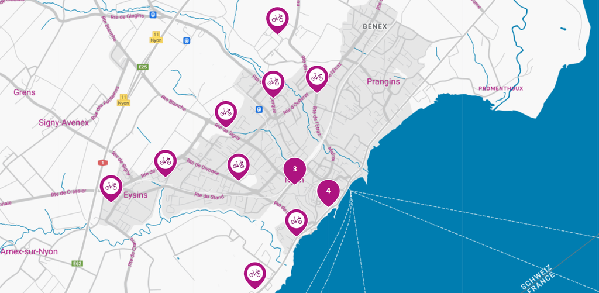

map

# Exploratory Data Analysis and Data Wrangling / Cleaning

## Data Wrangling

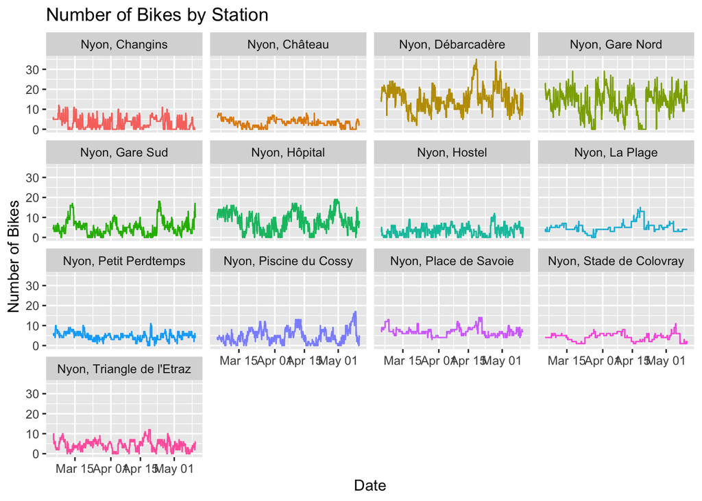

Variable demand across each station

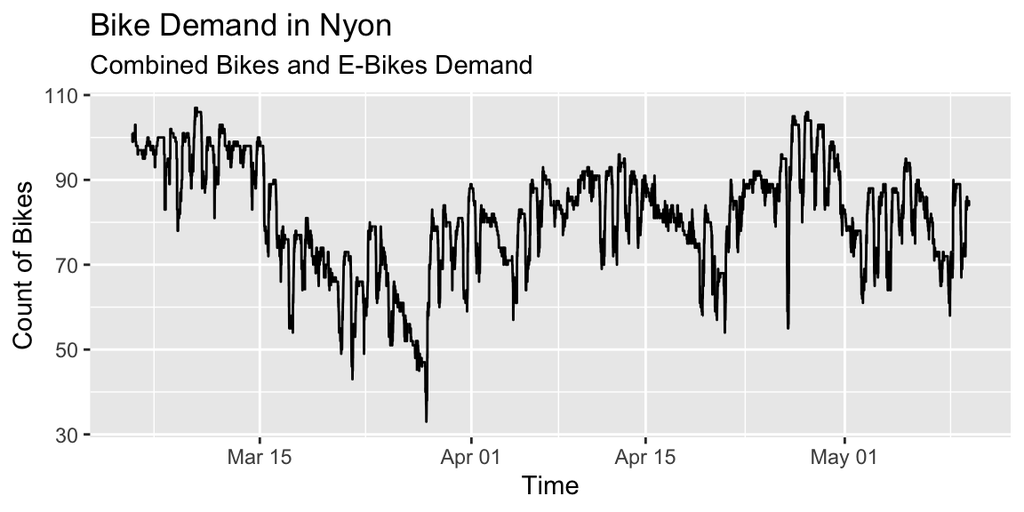

Bike and E-Bike Demand

Figure 3 shows that the total bike demand is erratic. There is a clear drop in the last week of March, possibly owing due to the snowy conditions in Western Switzerland.

As part of our data understanding process, we wanted to see whether there was a relationship or even a difference in demand between the normal bikes and the e-bikes. Therefore, we have calculated the correlation between them.

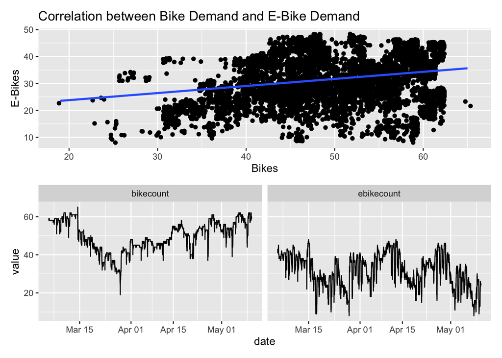

After studying the correlation, we could see a slight correlation between bikes and e-bikes but there wasn’t a huge difference between the demand on both so we have decided to combine them and wirk on “Total Bikes” instead.  
Intuitively, bike demand depends on a number of factors such as time of day, the day of the week, public holidays and the weather. The dataset already contains information that can be used to create new features such as `timeofday`, `weekday` and `holidays`. Data regarding holidays was extracted from the commune’s website.

The boxplots show how `TotalBikes` differs at each station depending on whether it’s a weekend or a weekday and whether the day in question is a public holiday (0 for No and 1 for Yes). In this time frame, the most relevant public holidays were: Easter and Labour Day.

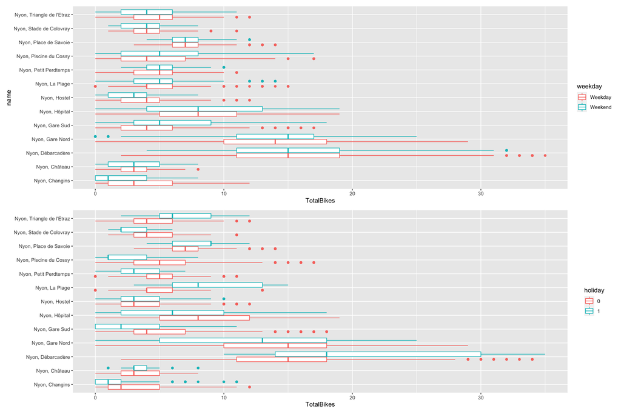

There doesn’t seem to be much variation in the total number of bikes available when it comes to weekdays vs weekends. However, there is a clear difference between holidays and non-holidays. Areas like La Plage have no demand on holidays such as Easter Monday and the number of bikes available at the station is very high.

Next, we add the weather data and see if it has an impact on the available bikes at each station. Weather data was accessed using `WorldWeatherOnline` API. WWO provides a number of metrics such as temperature, precipitation, visibility among many others. The assumption is that better weather leads to more bikes in demand.

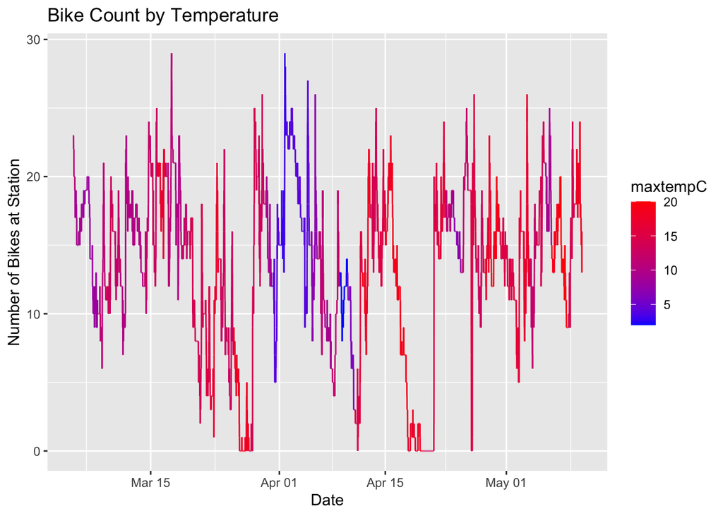

Correlation between temperature and number of bikes at station

We can see that there is some correlation between weather and the number of bikes. As the temperature is higher, there are fewer bikes available at a station, as the temperature is lower. There are more bikes available. Therefore, we will be accounting for the temperature in our forecast.

# Forecast

For our forecast, we have tried several forecasting models to get a closest forecast. After fitting several models, we have chosen TSLM (Time Series Linear Model) to fit the ofrecast as it provided best results along time.

…1

name

.model

date

TotalBikes

.mean

90%

1

<aggregated>

bu

2022-05-16 15:30:00

2

<aggregated>

bu

2022-05-16 15:40:00

68.3278510187092,[65.4834955513382, 71.1722064860802]90

3

<aggregated>

bu

2022-05-16 15:50:00

67.6003559135308,[64.1434571910496, 71.0572546360121]90

4

<aggregated>

bu

2022-05-16 16:00:00

71.0970977985291,[67.1208122902796, 75.0733833067785]90

5

<aggregated>

bu

2022-05-16 16:10:00

70.5746923402781,[66.1393625629857, 75.0100221175706]90

6

<aggregated>

bu

2022-05-16 16:20:00

69.8571786513947,[65.0060033420705, 74.7083539607189]90